# Lesson 1: Introduction to the course and regression

Last updated in January 2021

## About the course

## Context

This course is part of a cluster on quantitative methods (taught mostly in R) at the Department of Sociology. The cluster on quantitative methods is under development. We plan that it is all taught in English.

- Clusters are designed to facilitate specialization.
- There is always one core course in each cluster and a few complementary courses.

## Cluster on quantitative methods:

Already taught:

- Introduction to data analysis in R (recommended first)
- **Applied regression in R** (this course, CORE)

Planned:

- Generalized linear models in R
- Automated data collection and quantitative text analysis in R
- Social network analysis in R
- Statistical modeling for network data in R
- Design and evaluation of experimental studies

## Proposition

This course (as well as the entire cluster) is designed to be suitable for social scientists and their needs.

- conceptual understanding and practical skills
- little math (but we provide reference to relevant literature)

## Goals

After this course, students should:

- have a good conceptual understanding of linear regression and its various purposes
- command related terminology
- understand related assumptions, when they are relevant, how they can be checked, and how problems with assumptions can be treated
- make well-argued and defensible decisions when conducting their own regression analysis
- conduct regression analysis and report result and diagnostics in tables and charts

## Materials

- The course syllabus can found in the Student Information System [HERE](https://is.cuni.cz/studium/predmety/index.php?id=9638927780309b18b9e8f2d1c9c0e203&tid=&do=predmet&kod=ASGV00995)
- This course has a dedicated webpage with course materials, homework, assignment details, and slides at https://sociology-fa-cu.github.io/appliedregressioninr/

## Introduction to linear regression

## Goals for today

- Different usage of regression analysis
- Basic concepts (some, more will follow across the course)

## What is linear regression?

Regression is a method that allows researchers to summarize how predictions or average values of an *outcame* vary across individuals defined by a set of *predictors* (Gelman et al., 2020, p. 4)

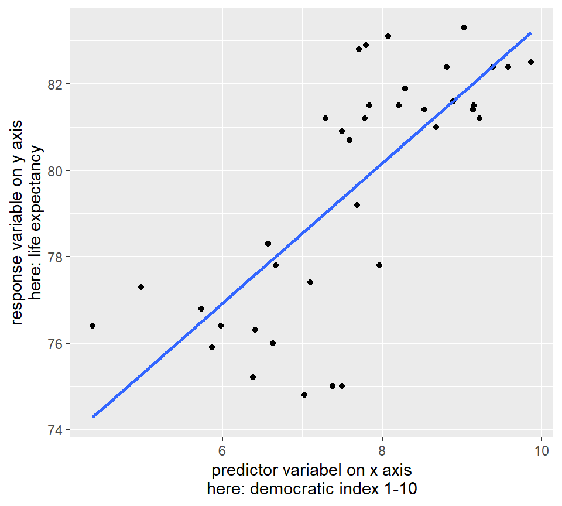

## Multiple linear regression

- More than one predictor term
- Careful, more terms does not necessarily mean more predictors!

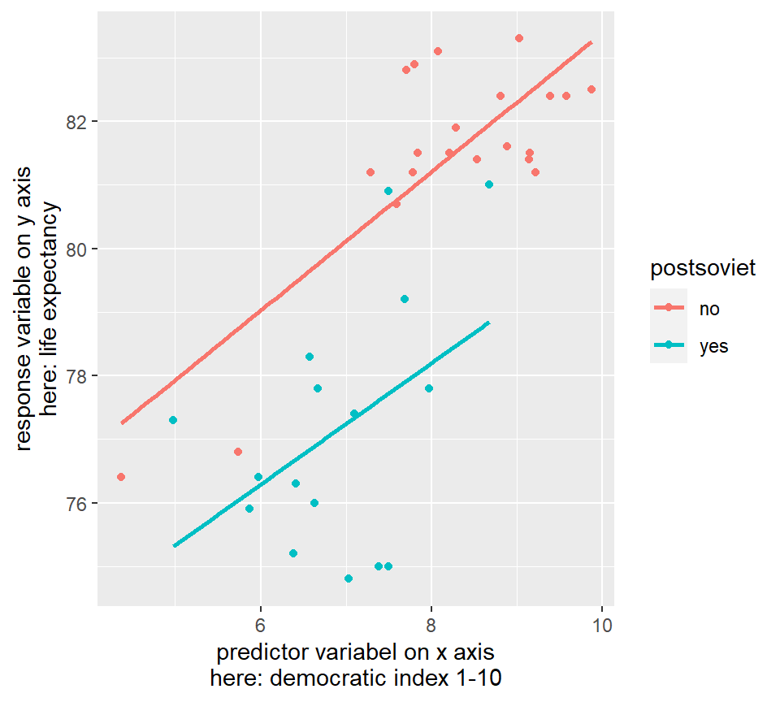

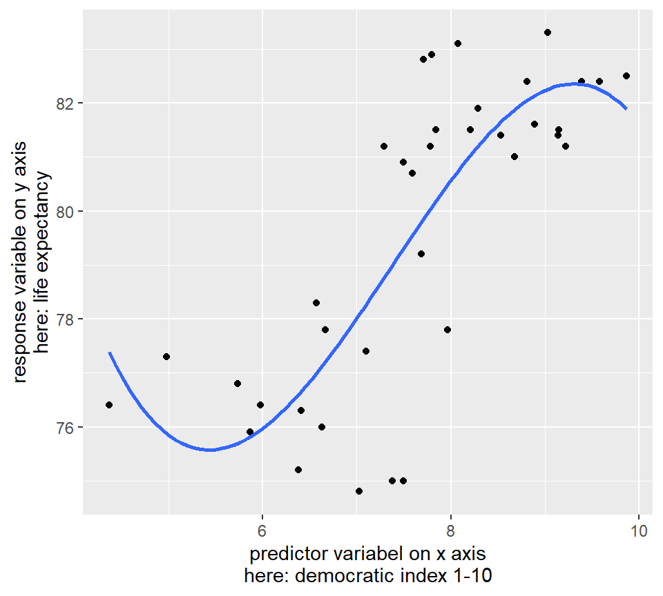

## List of all the things regression does:

- Detect relationships that can be expressed as linear combination of our predictors
- But it can only catch relationships you tell it to look for…

## So you better be sure the model is specified correctly…

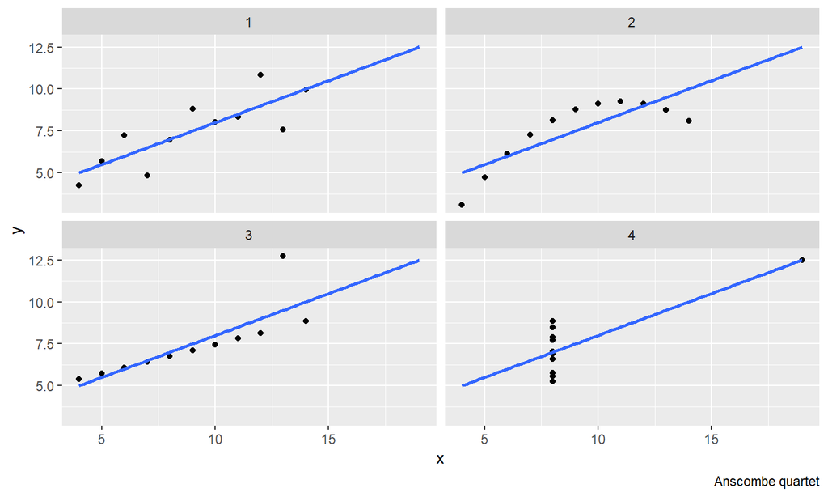

## So it does just the one thing, but it is used for many things

1. Descriptive modeling
2. Sample-to-population inference modeling
3. Predictive modeling
4. Causal inference modeling (aka explanatory modeling)

Computationally, all of these are still the same regression. But our different goals with regression have important implications for our assumptions and for what we report.

See Shmueli (2010) for details.

## Different purposes of modeling

## Descriptive modeling

- Goal: Summarizing or representing the data structure in a compact manner (capturing association)
- Focus on the measurable level (properties of the actually observed data)
- Few assumptions (but it is useful to check for non-linearity, remember Anscombe)
- Example: Did the voter turnout in the last elections differ across administrative regions with the same level of unemployment?

## Sample-to-population inference modeling

- Goal: Inferring form a sample properties of a population (too large to observe as a whole)
- Assumption that the data are sampled from a larger population in a representative manner (or that the data can be adjusted to make inference valid)
- Example: What is the relationship between age and voter turnout in the Czech republic?

## Causal inference / explanatory modeling

- Strong role of theory (the theory (not the data) justifies causality)
- Explanatory goals are related to the concept of truth: understand the underlying causal process, the true model
- The worst fear of explanatory modeling: bias (to be systematically wrong, invalid)
- Example: Does exposure to political advertisements increases citizens willingness to vote?

## Predictive modeling

- Predicting new or future observations
- Rare in social science academic papers
- Important in business, but also some other disciplines (epidemiology)
- Theory often less important, or not at all (data mining, machine learning)
- “Applied science” (practicality) as opposed to “Basic science”
- The worst fear of predictive modeling: large estimation variance (uncertainty)
- Example: Predicting likely voters in pre-election survey

## Summary on different types of modeling

- Descriptive modeling is about association(s): when using linear regression, check linearity of the association
- Sample-to-population inference modeling also makes use of confidence intervals and statistical hypothesis testing (and related assumptions), it is also important how the data was collected
- Explanatory and predictive modeling will be further contrasted against each other (while not incompatible, they are different strategies)

## Summary comparison of predictive and explanatory modeling 1/3

|  | Explanatory | Predictive |
| --- | --- | --- |
| Goal | Explanation | Prediction |
| Amount of data | Enough (statistical power) | As much as possible |
| Design | RCT as gold standard | Observational data with noise can be better |
| Design in multilevel | More groups preferred | More observations per group preferred |
| Operationalization | More flexibility | Should be the same for training and predicting |

## Summary comparison of predictive and explanatory modeling 2/3

|  | Explanatory | Predictive |
| --- | --- | --- |
| Measurement | Instrument validity (FA, IRT) | Measurement quality |
| Missing data | Drop cases or imputation | Cannot be dropped, possibly reduced models used |
| Data preparation | Partitioning rare | Partitioning common practice |
| EDA | Theory driven | Freestyle, interactivity |
| Dimension reduction | Interpretability (eg. rotation) | Freestyle |

## Summary comparison of predictive and explanatory modeling 3/3

|  | Explanatory | Predictive |
| --- | --- | --- |
| Choose variables | Defined by causal structure | Freestyle (eg. interaction without main effect OK) |
| Choose methods | Model with explicit functions | Also algorithmic (neural networks, ensembles,…) |
| Validation | Model fit, residual diagnostics | Overfitting |
| Reporting | Inference | Comparison across models in terms of predicting |

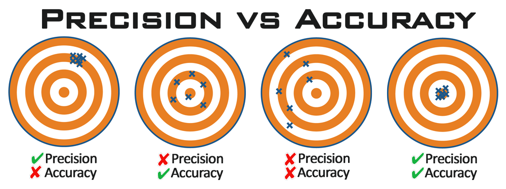

Similar to reliability vs validity or effectiveness vs unbiasedness

Source: https://flyingdonv.com/2016/03/07/get-your-geek-on-accuracy-precision-and-resolution-whats-the-difference-1/

## Conclusions on modeling approaches

- explanatory modeling focuses on causation, is theory-driven, retrospective, and its priority is minimizing bias
- predictive modeling focuses on prediction, is data-driven (interpretability is not neccessary for good predictions), prospective (practicality), and can accept some bias when this reduces variance (i.e. uncertainty)
- explanatory modeling is more developed within the field of statistics, predictive modeling within computer science

## What Shmueli (2010) thinks

- Predictive modeling should be used more in science because it can
  - Generating new hypotheses about causal mechanisms (theory-free exploration)
  - Help assess usefulness of explanatory theories for practical application
- In addition, understanding predictability also means understanding un-predictability, which is theoretically important (Taleb, 2007).

“An explanatory model that is close to the predictive benchmark may suggest that our understanding of that phenomenon can only be increased marginally. On the other hand, an explanatory model that is very far from the predictive benchmark would imply that there are substantial practical and theoretical gains to be had from further scientific development.” (Shmueli, 2010)

Note that the authors of Regression and Other Stories (Gelman et al., 2020) frame all statistical inference as problems of prediction. Words are often used differently…

## Linear regression: some basic building blocks

## Bivariate linear regression formula: y = α + βx

- α, sometimes also β0, is the intercept, i.e. the value of Y when X = 0
- β, sometimes also β1, is the slope, i.e. rate of change in Y when X changes by 1 unit

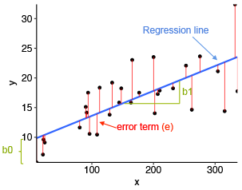

Source: http://www.sthda.com/english/articles/40-regression-analysis/167-simple-linear-regression-in-r/

## The line and the points

- The formula y = α + βx represents the line
- But the observed value of Y is usually below or above the line… “the stochastic nature of the dependent variable”
- Assumption: randomness in the real World
- For convenience in regression: X fixed, Y stochastic
- The actual value of Y = linear model + stochastic error term
- Y = α + βx + ε

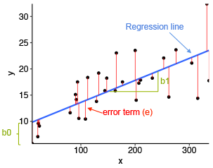

Source: http://www.sthda.com/english/articles/40-regression-analysis/167-simple-linear-regression-in-r/

## Error vs. Residual

- Error = difference between the real value of Y and the real average value of Y for given X
- Residual = difference between our observed value of Y and our regression model

In other words, errors are the deviations of the theoretical (i.e. measured without measurement error) observations from the real population conditional mean. Residuals are the deviations of the actual observations we have from the sample conditional mean. Or in other words: observable estimates of the unobservable stochastic errors.

## Ordinary least square (OLS)

- Another name for simple linear regression
- The model is estimated by minimizing the sum of squares of residuals (RSS). This by definition results in having a sum of residuals equal 0.
- \(\small Sum\:of\:squares=-2^2+1.1^2+\\\small2.8^2+(-4)^2+\\\small1.6^2+1.8^2+\\\small(-0.3^2)+(-0.2^2)+\\\small(-0.1^2)+(-0.7^2)=35.3\)

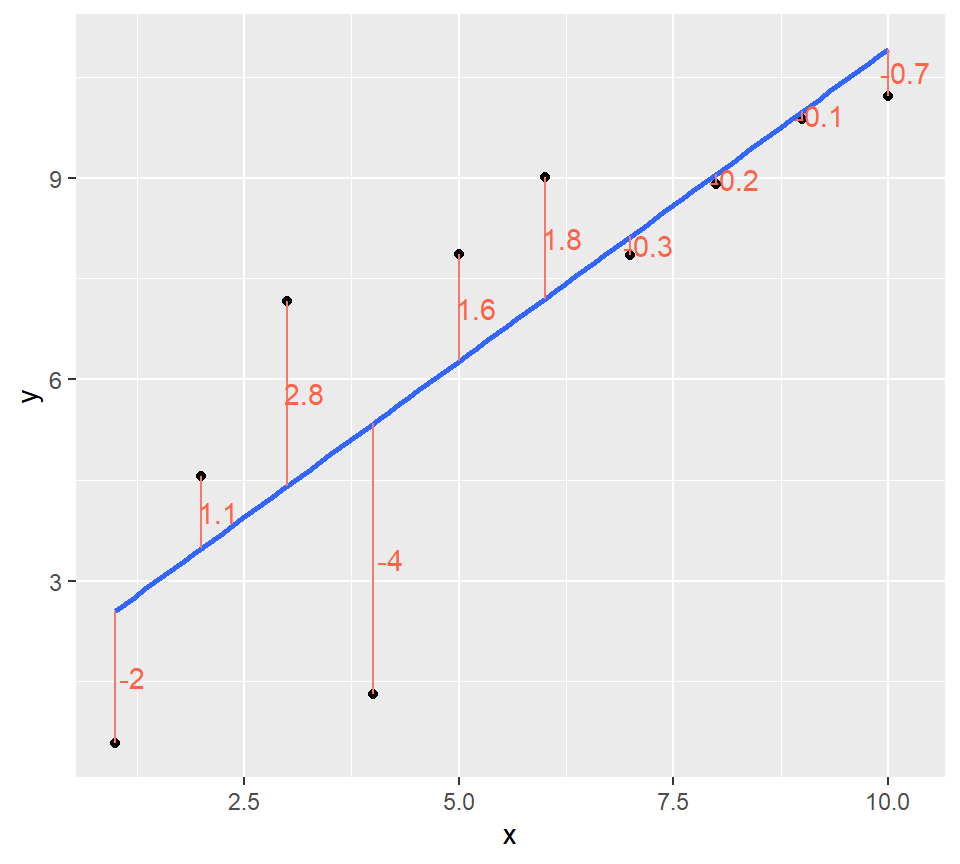

- For details on how OLS is calculated, see Fox (2015, p. 83)

## Not used

- Different paradigms:
  - Classical statistics, Error statistics, NHT, Frequentist approach (probability of data given hypothesis)
  - Bayesian inference (probability of hypothesis given data and prior belief)
  - (Maximum likelihood estimation; AIC based inference for model selection)

## References

Fox, J. (2015). *Applied regression analysis and generalized linear models* (Third edition). SAGE Publications, Inc.

Gelman, A., Hill, J., & Vehtari, A. (2020). *Regression and other stories*. Cambridge University Press. https://doi.org/10.1017/9781139161879

Shmueli, G. (2010). *To Explain or To Predict?* https://doi.org/10.2139/ssrn.1351252

Taleb, N. N. (2007). Black Swans and the Domains of Statistics. *The American Statistician*, *61*(3), 198–200. https://doi.org/10.1198/000313007x219996